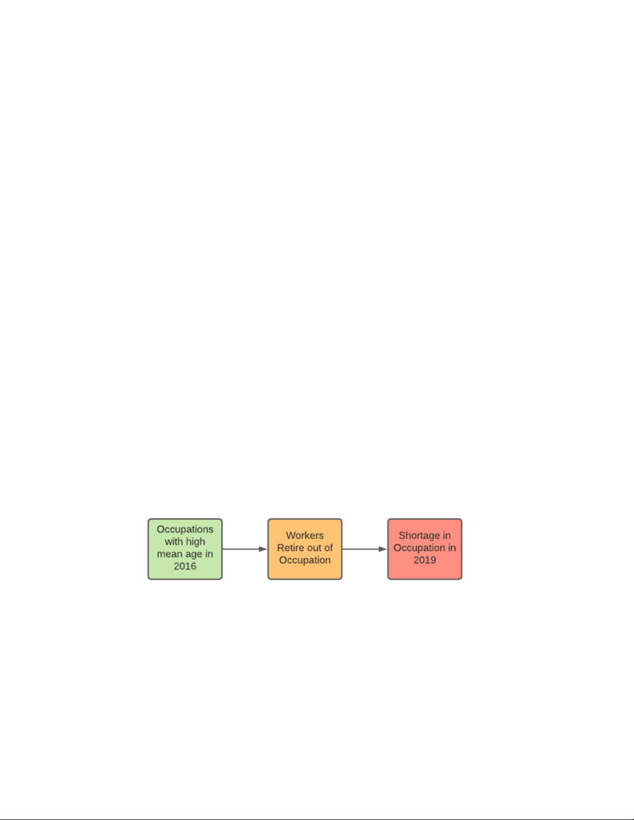

Stat 433 Final Project Report

Taran Katta, Nolan Peterson, Mark Wu

12/16/2021

Introduction

The aim of this project is to analyze the relationship between age in occupational sectors and labor shortages

within occupational sectors in Wisconsin. Furthermore, we wish to test how well labor shortages can be

predicted using ages within said occupational sectors. The motivation behind exploring this relationship

is that there is a commonly held idea that jobs which are held mostly by older workers are more prone to

shortages. For instance, the average age of farm workers in Wisconsin is 53, which is considerably greater than

the average age of all workers in Wisconsin. Additionally there is a shortage of farm workers in Wisconsin.

It would be logical to assume that there is a connection between these two facts. However, every assumption

must be supported by data and careful statistical analysis. In this report we will explore this assumption.

We will examine ages within occupations in 2016 and examine shortages within those same occupations in

2019. This hypothesized relationship is visualized in ﬁgure 1.

Figure 1: Theorized relationship between Age and Shortage

After careful analysis we found that the data does not necessarily support this assumption.

1

[figure not shown]

Thesis Statments

In this paper we argue that the average age within occupational sectors in Wisconsin has no signiﬁcant

bearing on the probability of labor shortage in that occupational sector. And furthermore, there is no

signiﬁcant relationship between average age within occupational sectors and shortages in occupations in

Wisconsin.

Data

The data sources and related information can be found in appendix Section 1.1.

The code relating to this section can be found in appendix Section 1.2.

The data for this project come from two primary sources. The ﬁrst is American Community Survey (ACS)

The ACS data for 2016 and 2019 together was 118,336 observations with 288 variables. The vast majority of

these variables were not useful to answering our research question. Consequently only the following variables

were selected from the ACS data: OCCP (Occupational Code), AGEP (Age of the Person), PWGTP

(Replicate Weight Estimate) and ESR (Employment Status). This subset of data was then grouped by year

and occupation code, so that a weighted estimate could be constructed of the mean age within occupations

and unemployment rate within occupations. The result was data set with 4 variables and 996 observations

representing approximately 498 occupations across two years (2016 and 2019).

This grouped data frame was joined to the OEWS data for Wisconsin for 2016 and 2019 by occupation

code. Because there are fewer ACS occupational codes than there are OWES occupational codes, this means

that ACS codes tend to be broader and represent more occupations that OWES code. Using a crosswalk

key between these two code systems it was determined which codes mapped to each other. In instances

where there was multiple OEWS codes for one ACS code, the OEWS observations were merged into one

observation. Additionally there were occupations were the sample sized collected was too small to estimate

unemployment rates within that occupational sector. These occupations were dropped from the data set,

for reasons that will be explained in more detail in the methods section. With this cleaned and joined data

estimates of job growth rate and wage growth rate could be constructed. These were added to the data set

as additional variables. And ﬁnally the data was pivoted wider by year so there was individual variables for

both 2016 and 2019. The 79 observation was dropped from the data because it was a very extreme outlier

in Job growth rate. The ﬁnal data set has 83 observations and 22 variables. The steps for the data ﬁltering

cleaning and joining are summarized in ﬁgure 2.

2

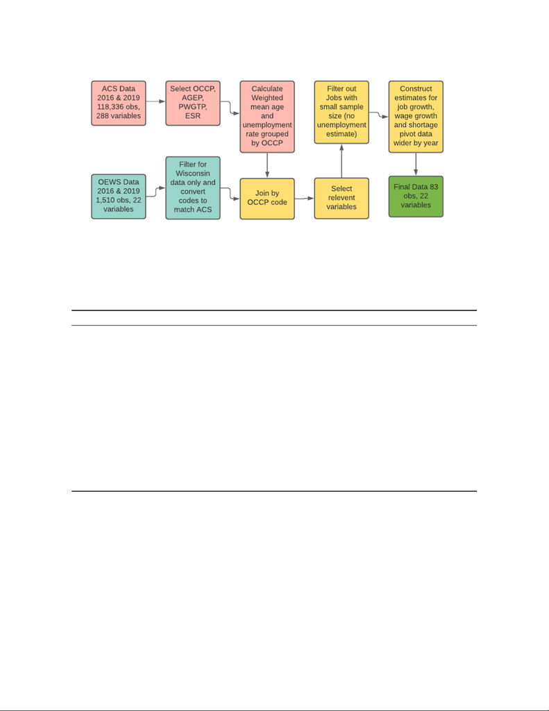

Figure 2: Data Pre-processing Summarized

This is a table summarizing the variables in ﬁnal data set:

Variable Name Explanation

OCCP ACS Occupational Code

ACS Occupational Title Title of Occupation

mean_age_(2016 or 2019) Average Age of Worker in Occupation

unemployed_rate_(2016 or 2019) Unemployment Rate

total_employ_(2016 or 2019) Total Number of Jobs in Occupation

employ_prse_(2016 or 2019) Standard Error of Employment Estimate

jobs_per_1000_(2016 or 2019) Share of Jobs per 1000 that Occupation Makes Up

mean_hourly_(2016 or 2019) Mean Hourly Wage of Workers in Occupation

mean_annual_(2016 or 2019) Mean Annual Salary of Workers in Occupation

mean_prse_(2016 or 2019) Standard Error of Salary Estimate

emp_growth Estimate of Mean Employment Growth in Occp. from 2016 to

2019

wage_growth Estimate of Mean Wage Growth in Occp. from 2016 to 2019

shortage_ind A Binary Recode of Shortage, 0 = No Shortage, 1 = Shortage

Shortage Does Occupation have Shortage or No Shortage

Methods

Deﬁning a Labor Shortage

A primary challenge of this project was identifying labor shortages in the 2019 data. A labor shortage has

An occupational shortage is deﬁned by three criteria:

1. The occupation’s employment growth rate is faster than average employment growth

2. The wage increase is faster than average.

3

[figure not shown]

3. The occupation’s unemployment rate is below average.

In order to deﬁne a shortage, it was necessary to ﬁrst construct estimates of the employment growth rate

and wage growth rate. As mentioned in the data section of this report, these estimates were calculated from

OEWS data from 2016 and 2019. The formulas used to do so can be found below.

Average Annual Employment Growth =

2019

Employment

2016

×

1

3 Y ears − 1

× 100%

Average Annual W age Growth =

Avg Salary

2019

Avg Salary

2016

×

1

3 Y ears − 1

× 100%

The unemployment rate used is the unemployment in 2019.

With these criteria we were able to identify 12 occupations with shortages and 71 without shortages.

T-test

In this analysis a t-test was used to compare the sample means of ‘average worker age in occupation’ in

occupations suﬀering from shortages and those not suﬀering from shortages. In general the t-test has the

following form:

t

obs

=

¯x

1

− ¯x

2

q

σ

2

1

n1

+

σ

2

2

n

2

This value is then compared to the tail critical values from the student’s t-distribution.

obs

form:

(¯x

1

− ¯x

2

) ± t

obs

× S

p

×

r

1

n

1

+

1

n

2

Where S

p

is the pooled sample standard deviation and has the form:

S

p

=

s

(n

1

− 1)σ

2

1

+ (n

2

− 1)σ

2

2

n

1

+ n

2

− 2

Logistic Regression

In general logistic models have the form:

logit(π) = β

0

+ β

1

x

1

+ ... + β

n

x

n

Where π is the probability of success in a binary outcome. The model utilizes logit transformation, log(

π

1−π

),

in order to bind the linear prediction equation between 0 and 1. In this analysis we use a logistic regression

model to predict the probability of labor shortages.

4

[figure not shown]

Wald Conﬁdence Intervals for Predictor eﬀect

Wald conﬁdence intervals can be constructed around the eﬀects of the predictors, in order to gauge their

signiﬁcance in the model. In general the 100(1 − α)% Wald interval for predictor eﬀect has the following

form:

exp

ˆ

β

1

± Z

1−α/2

q

ˆ

V ar(

ˆ

β

1

)

We plan to construct a Wald conﬁdence interval around the eﬀect of ‘mean age of work in occupation’ in a

logistic regression model.

Wald Test for Predictor Signifcance

Similar to the Wald Conﬁdence Intervals for predictor eﬀect, a Wald test for signiﬁcance of a predictor in a

logistic regression model can also be preformed. A Wald test has the general form:

Z

0

=

ˆ

β

r

q

V ar(

ˆ

β

r

)

The value is compared to critical values of a standard normal distribution. For example to test at the 95%

conﬁdence level, |Z

0

| would be compared against 1.96. We plan to use a Wald test to test the signiﬁcance of

‘mean age of work in occupation’ in a logistic regression model.

Firth’s Logistic Regression

Firth’s Logistic Regression is a modiﬁed form of logistic regression that adds a penalty to Fisher’s Scoring

function. This improves models that are ﬁt on small or imbalanced data sets (Builder, 2015 page 114). We

intend to ﬁt a Firth logistic regression model on the data to predict the probability of shortage because the

data set is relatively imbalanced (71 no shortages, 12 shortages).

5

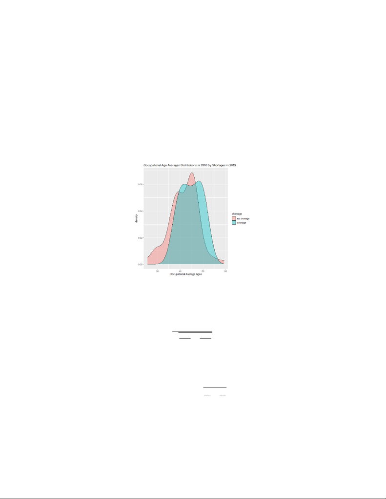

Results

T-test for diﬀerence in Sample Means

The code relating to this section can be found in appendix Section 2.1.

With the labor shortage properly deﬁned we sought to test the following hypothesis:

H

0

: Mean of all occupation age averages in shortage group = Mean of all occupation age averages in

non-shortage group

H

a

non-shortage group

This can be visually explained by looking at the density plots of the ages for these two groups in ﬁgure 3.

Code for the density plots can be found in appendix Section 2.2.

Figure 3: Density plots of age for shortage and non-shortage

An appropriate method to test hypothesis is a t test for diﬀerence of sample means. In our case the t-test

statistic was calculated as such:

t

obs

=

44.80 − 41.75

q

4.79

2

12

+

6.19

2

71

= 1.95

The upper tail critical value is 1.990. This comparison yields a p-value of 0.054. Which would lead us to fail

to reject the null hypothesis at the α = 0.05 level.

When the 95% conﬁdence interval for diﬀerence of sample means was calculated this was the result:

1

12

+

1

71

= (−0.684, 6.78)

As can be seen in the above interval for diﬀerence of means 0 is at the far end of the interval but not excluded

from it indicating that even at the 95% conﬁdence level the possibility that the diﬀerence in population means

is 0 should not be excluded. Again the null hypothesis is not rejected.

6

[figure not shown]

Logistic Regression Model

The code relating to this section can be found in appendix Section 3.

In the data set a shortage indicator variable was created. It indicates 0 for no shortage and 1 for shortage.

We constructed a logistic regression model to predict the probability of shortage.

Here π represents the probability of shortage and we only have a sole predictor; mean age in 2016.

So our model once it was ﬁt looks like this:

logit(π) = −5.67 + 0.09 × AGE

In this model the coeﬃcient of age has the interpretation that with every year the mean age of workers in

an occupation is increased the odds of shortage increase by 9.42%. A Wald 95% conﬁdence interval can

be constructed for the eﬀect of this predictor in R using confint() function. The result is that with 95%

conﬁdence it can be said that with every year the mean age of workers in an occupation is increased the

odds of shortage are increased or decreased somewhere in the range of −2.07% to 22.23%.

It can be seen that zero percent change is within the above conﬁdence interval indicating that it is possible

that mean age of workers in an occupation may have a null eﬀect on the probability of labor shortage. To

test this concretely we performed a Wald test for signiﬁcance of predictor.

H

0

: Mean age is not a signiﬁcant predictor.

H

a

: Mean age is a signiﬁcant predictor.

In our case the Wald test statistic is calculated as follows:

Z

0

=

0.08992

0.05653

= 1.59 < 1.96 = Z

crit

So in this case we fail to reject null hypothesis.

7

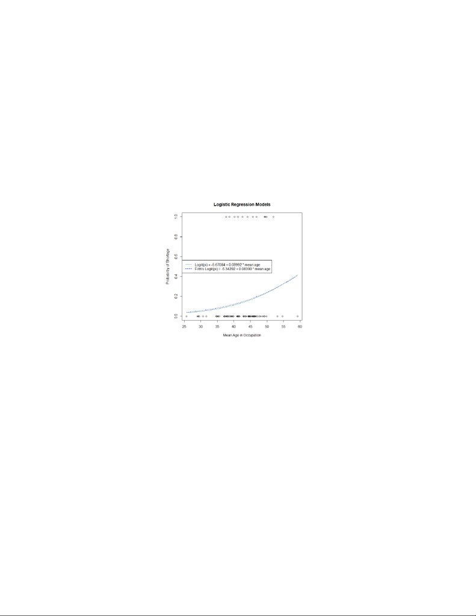

Firth’s Logistic Regression

The code relating to this section can be found in appendix Section 3.

As mentioned in the methods section Firth’s modiﬁed logistic regression can be used to improve model

performance on imbalanced data sets. When the ordinary logistic regression was not showing signiﬁcance

for mean age as a predictor, we turned our attention to ﬁtting a Firth logistic regression model in hopes that

could address the imbalance within our data. The resulting model was:

logit(π) = −5.34 + 0.08 × AGE

This model also did not render a signiﬁcant predictor. As can be seen in ﬁgure 4, there is little diﬀerence

between the Firth Logistic regression model and the ordinary logistic regression model. And neither of them

ﬁt very well.

Figure 4: Firth and Ordinary Logistic regression Models over layed on Data

Shiny App

In order for the reader to easily explore the data for themselves, we have written a Shiny app. It can be

accessed and ran by clicking on the link below.

https://nolan-peterson.shinyapps.io/JobApp/

Conclusion

From the statistical analysis preformed, it can be inferred that there is no strong relationship between the

average age of a workers a in occupation in 2016 and shortage status of the occupation in 2019 or the

probability of shortage in occupations in 2019 in Wisconsin. However, there are limitations to this analysis.

To start with there was only available data for 83 occupations. Within that we are only analyzing the mean

age of workers by occupation. The mean is not a robust measure when outliers are introduced into the data.

Furthermore no confounding variables were controlled for in the models. In the future we would like to

incorporate more variables into the model. Some variables that we speculate may be desirable are, average

education level of occupation, geographical concentration of occupation and broad industry classiﬁcation of

occupation.

8

[figure not shown]

References

1. Veneri, Carolyn M. ”Can occupational labor shortages be identiﬁed using available data.” Monthly

Lab. Rev. 122 (1999): 15.

2. Hertz, Tom, and Steven Zahniser. ”Is there a farm labor shortage?.” Amer-ican Journal of Agricultural

Economics 95.2 (2013): 476-481.

3. Barnow, Burt & Trutko, John & Piatak, Jaclyn. (2013). How Do We Know Occupational Labor

Shortages Exist?. Employment Research. 20. 4-6. 10.17848/1075-8445.20(2)-2.

4. Bilder, Christopher R., and Thomas M. Loughin. Analysis of Categorical Data with R. CRC Press,

Taylor & Francis Group, 2015.

Appendix

Appendix Section 1.1 Data Soucres

Link to ACS 2016 personal Wisconsin data:

https://www2.census.gov/programs-surveys/acs/data/pums/2016/1-Year/csv_pwi.zip

Link to ACS 2019 personal Wisconsin data:

https://www2.census.gov/programs-surveys/acs/data/pums/2019/1-Year/csv_pwi.zip

Link to ACS 2015-2019 personal data, data dictionary:

https://www2.census.gov/programs-surveys/acs/tech_docs/pums/data_dict/PUMS_Data_Dictionary_

2015-2019.pdf

Link to OEWS 2016 state data:

https://www.bls.gov/oes/special.requests/oesm16st.zip

Link to OEWS 2019 state data:

https://www.bls.gov/oes/special.requests/oesm19st.zip

Link to ACS to OEWS OCCP code crosswalk key:

https://www.bls.gov/emp/classiﬁcations-crosswalks/nem-occcode-acs-crosswalk.xlsx

Appendix Section 1.2 Data Cleaning

## Library Statements

library(tidyverse)

library(readxl)

library(BBmisc)

## All data can be found at https://github.com/NolanPeterson453/Stat-433-Project

## Read in the ACS data for 2016 and 2019

ACS_16_raw <- read_csv(file =

’https://raw.githubusercontent.com/NolanPeterson453/Stat-433-Project/main/ACS_WI_2016.csv’)

ACS_19_raw <- read_csv(file =

’https://raw.githubusercontent.com/NolanPeterson453/Stat-433-Project/main/ACS_WI_2019.csv’)

9

## Select the variables OCCP (occupation), AGEP (age), PWGTP (sample weight)

ACS_16 <- select(ACS_16_raw, OCCP, AGEP, PWGTP, ESR)

ACS_19 <- select(ACS_19_raw, OCCP, AGEP, PWGTP, ESR)

## Add variable YEAR that tells what year observation comes from

ACS_16 <- mutate(ACS_16, YEAR = rep(2016, length(PWGTP)))

ACS_19 <- mutate(ACS_19, YEAR = rep(2019, length(PWGTP)))

## Fixing column types for easy binding

ACS_16 <- lapply(ACS_16, as.numeric)

ACS_19 <- lapply(ACS_19, as.numeric)

## Combine the data

comb_ACS <- bind_rows(ACS_16, ACS_19)

## Convert OCCP back to character

comb_ACS$OCCP <- as.character(comb_ACS$OCCP)

## Create a data frame that gives the weighted average age for each occupation in each year

## and unemployment rate for each occupation by year

mean_age_occp <- comb_ACS %>%

group_by(OCCP, YEAR) %>%

mutate(weight = PWGTP / sum(PWGTP)) %>%

summarise(mean_age = sum(AGEP * weight, na.rm = TRUE),

unemployed_rate = (sum(PWGTP[which(ESR == 3)], na.rm = TRUE) /

sum(PWGTP, na.rm = TRUE)) * 100 )

## Load in OES data and get the Wisconsin data only ##

OES_16_raw <- read_excel(’state_M2016_dl.xlsx’,1)%>%

filter(STATE=="Wisconsin")%>%

mutate(YEAR=2016)%>%

select(-ST)

OES_19_raw <- read_excel(’state_M2019_dl.xlsx’,1)%>%

rename(STATE=area_title,OCC_GROUP=o_group,LOC_Q=loc_quotient)

names(OES_19_raw)<-toupper(names(OES_19_raw))

OES_19_raw <-OES_19_raw%>%

filter(STATE=="Wisconsin")%>%

mutate(YEAR=2019)%>%

select(-AREA_TYPE,-NAICS,-NAICS_TITLE,-I_GROUP,-OWN_CODE,-PCT_TOTAL)

## Stack both years into one data frame

comb_OES <- rbind(OES_16_raw, OES_19_raw)

## Function to create header

header.true <- function(df){

names(df) <- as.character(unlist(df[1,]))

df[-1,]

}

## Read in crosswalk code key data and format it

10

key <- read_excel(’nem-occcode-acs-crosswalk.xlsx’,1)[-c(1,2,3), ] %>%

header.true() %>%

rename(OCC_CODE = ’Hybrid SOC Code’,

OCCP = ’ACS Code’)

## Join Key and OES data

comb_OES_KEY <- comb_OES %>%

left_join(key, by = "OCC_CODE") %>%

mutate(OCCP = OCCP)

## Join OES and ACC data frames

comb_ACS_OES_KEY <- mean_age_occp %>%

left_join(comb_OES_KEY, by = c("OCCP", "YEAR"))

## Select the useful variables

comb_ACS_OES_KEY <- comb_ACS_OES_KEY %>%

select(YEAR, OCCP, mean_age, unemployed_rate,

OCC_CODE, OCC_TITLE, TOT_EMP, EMP_PRSE,

JOBS_1000, H_MEAN, A_MEAN, MEAN_PRSE)

## Filter out rows where sample size is too small to collect unemployment data

## And filter out rows where OES and ACS have no comparison

comb_ACS_OES_KEY <- comb_ACS_OES_KEY %>%

filter(unemployed_rate != 0,

unemployed_rate != 100,

!is.na(OCC_TITLE))

## Assign NA to missing values in the data

## Assign data types to numeric and factor variables

## Remove NA’s from data

comb_ACS_OES_KEY[comb_ACS_OES_KEY == "*" | comb_ACS_OES_KEY == "**"] <- NA

comb_ACS_OES_KEY[,7:12] <- as.data.frame(sapply(comb_ACS_OES_KEY[,7:12], as.numeric))

comb_ACS_OES_KEY <- comb_ACS_OES_KEY %>%

filter(!is.na(OCCP))

comb_ACS_OES_KEY$YEAR <- as.factor(comb_ACS_OES_KEY$YEAR)

## Reconcile difference in acs coding system oes coding system

cleaned_data <- comb_ACS_OES_KEY %>%

group_by(YEAR, OCCP) %>%

summarise(mean_age = mean(mean_age, na.rm = TRUE),

unemployed_rate = mean(unemployed_rate, na.rm = TRUE),

total_employ = sum(TOT_EMP, na.rm = TRUE),

employ_prse = mean(EMP_PRSE, na.rm = TRUE),

jobs_per_1000 = sum(JOBS_1000, na.rm = TRUE),

mean_hourly = mean(H_MEAN, na.rm = TRUE),

mean_annual = mean(A_MEAN, na.rm = TRUE),

mean_prse = mean(MEAN_PRSE, na.rm = TRUE))

## Create a clean 2016 data

cleaned_data_2016 <- cleaned_data %>%

filter(YEAR == 2016 )

11

## Create a clean 2019 data

cleaned_data_2019 <- cleaned_data %>%

filter(YEAR == 2019 )

## Join these two data set to get Year specific columns (x = 2016, y = 2019)

## could possibly be done with ’pivot_wider’ but I had no luck

## Filter out where no jobs in 2016

cleaned_data <- inner_join(cleaned_data_2016, cleaned_data_2019, by = "OCCP") %>%

filter(jobs_per_1000.x != 0)

## Create comparison variables

cleaned_data <- cleaned_data %>%

mutate(emp_growth = (jobs_per_1000.y / jobs_per_1000.x) * (1/(3 - 1)),

wage_growth = (mean_annual.y / mean_annual.x) * (1/(3 - 1)))

## Row 79 is a huge outlier in employment growth

cleaned_data <- cleaned_data[-79,]

## Create indicator for shortage (0 = no shortage, 1 shortage)

cleaned_data <- cleaned_data %>%

mutate(shortage_ind = ifelse(test = ( (emp_growth > mean(emp_growth)) &

(wage_growth > mean(wage_growth)) &

(unemployed_rate.y < mean(unemployed_rate.y))),

yes = 1,

no = 0),

shortage = ifelse(test = (shortage_ind == 1),

yes = "Shortage",

no = "No Shortage")) %>%

select(-c( YEAR.x, YEAR.y))

## Rename variables for clarity

cleaned_data <- cleaned_data %>%

rename(mean_age_2016 = mean_age.x,

mean_age_2019 = mean_age.y,

unemployed_rate_2016 = unemployed_rate.x,

unemployed_rate_2019 = unemployed_rate.y,

total_employ_2016 = total_employ.x,

total_employ_2019 = total_employ.y,

employ_prse_2016 = employ_prse.x,

employ_prse_2019 = employ_prse.y,

jobs_per_1000_2016 = jobs_per_1000.x,

jobs_per_1000_2019 = jobs_per_1000.y,

mean_hourly_2016 = mean_hourly.x,

mean_hourly_2019 = mean_hourly.y,

mean_annual_2016 = mean_annual.x,

mean_annual_2019 = mean_annual.y,

mean_prse_2016 = mean_prse.x,

mean_prse_2019 = mean_prse.y)

## Tack back on names

cleaned_data <- left_join(cleaned_data, key[,4:5], by = "OCCP") %>% distinct()

12

[figure not shown]

write.csv(cleaned_data, file = "cleaned_data_433.csv", row.names = FALSE)

Appendix Section 2.1 T-Test

# H_0: Mean_age_shortage_group = Mean_age_no_shortage_group

# H_a: Mean_age_shortage_group != Mean_age_no_shortage_group

data <- read.csv(file =

"https://raw.githubusercontent.com/NolanPeterson453/Stat-433-Project/main/cleaned_data_433.csv")

n_1 <- length(data$OCCP[data$shortage == "Shortage"])

n_2 <- length(data$OCCP[data$shortage == "No Shortage"])

x_bar_1 <- mean(data$mean_age_2016[data$shortage == "Shortage"])

x_bar_2 <- mean(data$mean_age_2016[data$shortage == "No Shortage"])

sd_1 <- sd(data$mean_age_2016[data$shortage == "Shortage"])

sd_2 <- sd(data$mean_age_2016[data$shortage == "No Shortage"])

t_obs <- (x_bar_1 - x_bar_2) / sqrt(sd_1^2 / n_1 + sd_2^2 / n_2) #1.948891

t_crit <- qt(p = 0.05/2, df = n_1 + n_2 - 2, lower.tail=FALSE) #1.989686

p_value <- 2 * pt(q = t_obs, df = n_1 + n_2 - 2, lower.tail=FALSE) # 0.05477044

# 95% Confidence intervals for difference in pop means using the t test statistic

S_p <- sqrt(((n_1 - 1) * sd_1^2 + (n_2 - 1) * sd_2^2 ) / (n_1 + n_2 - 2)) #6.016206

lower <- (x_bar_1 - x_bar_2) - t_crit * S_p * sqrt(1/n_1 + 1/n_2) #-0.6844983

upper <- (x_bar_1 - x_bar_2) + t_crit * S_p * sqrt(1/n_1 + 1/n_2) #6.787841

Appendix Section 2.2 Density Plots

library(tidyverse)

cleaned_data %>%

ggplot(aes(x = mean_age_2016, fill = shortage)) + geom_density(alpha = 0.4) +

labs(title = "Occupational Age Averages Distributions in 2016 by Shortages in 2019",

x = "Occupational Average Ages")

13

[figure not shown]

Appendix Section 3 Logistic Models

library(brglm)

## Model of shortage predicted by age

model <- glm(shortage_ind ~ mean_age_2016, family = binomial,

data = cleaned_data)

summary(model)

## Firth model

firth_model <- brglm(shortage_ind ~ mean_age_2016, family = binomial,

data = cleaned_data, pl = TRUE)

summary(firth_model)

# Model confidence interval

(exp(confint.default(model, pram = "mean_age_2016", level = 0.95)) -

1) * 100

## Plot models

plot(x = cleaned_data$mean_age_2016, y = cleaned_data$shortage_ind,

main = "Logistic Regression Models", xlab = "Mean Age in Occupation",

ylab = "Probabiltiy of Shortage")

curve(expr = predict(model, newdata = data.frame(mean_age_2016 = x),

type = "response"), add = TRUE, col = "seagreen", lty = 1)

curve(expr = predict(firth_model, newdata = data.frame(mean_age_2016 = x),

type = "response"), add = TRUE, col = "blue", lty = 2)

legend("left", legend = c("Logit(pi) = -5.67084 + 0.08992 * mean age",

"Firth’s Logit(pi) = -5.34202 + 0.08390 * mean age"), col = c("seagreen",

"blue"), lty = 1:2)

14